# Deep_Nueral_Network_Credit_Card_Churn

Background and Context

Businesses like banks that provide service have to worry about the problem of 'Churn' i.e. customers leaving and joining another service provider. It is important to understand which aspects of the service influence a customer's decision in this regard. Management can concentrate efforts on the improvement of service, keeping in mind these priorities.

Objective

Given a Bank customer, build a neural network-based classifier that can determine whether they will leave or not in the next 6 months.

Data Dictionary

- RowNumber : Row number.
- CustomerId : Unique identification key for different customers.
- Surname : Surname of the customer
- Credit Score : A credit score is a measure of an individual's ability to pay back the borrowed amount. It is the numerical representation of their creditworthiness. A credit score is a 3-digit number that falls in the range of 300-900, 900 being the highest.
- Geography: The country to which the customer belongs.
- Gender: The gender of the customer.
- Age: Age of the customer.
- Tenure: The period of time a customer has been associated with the bank.
- Balance: The account balance (the amount of money deposited in the bank account) of the customer.
- NumOfProducts: How many accounts, bank account affiliated products the person has.
- HasCrCard: Does the customer have a credit card through the bank?
- IsActiveMember: Subjective, but for the concept
- EstimatedSalary: Estimated salary of the customer.
- Exited: Did they leave the bank after all?

## Import all necessary libraries

```python
import warnings
warnings.filterwarnings("ignore")
import pandas as pd
import numpy as np
from sklearn.model_selection import train_test_split
import tensorflow as tf
from sklearn import preprocessing
from tensorflow.keras.models import Sequential
from tensorflow.keras.layers import Dense, Dropout
from sklearn.metrics import accuracy_score, confusion_matrix, precision_score, recall_score, f1_score, precision_recall_curve, auc
import matplotlib.pyplot as plt
from tensorflow.keras import optimizers
from sklearn.decomposition import PCA
import seaborn as sns
import keras
import tensorflow as tf
from keras import backend as K
from keras.models import Sequential
from keras.layers import Dense, Dropout
from keras.optimizers import Adam
from numpy import argmax
```

## Importing data

```python
#reading dataset
ccdata = pd.read_csv("/content/bank.csv")
```

## Overview of Dataset

```python
ccdata.head()
```

|  | RowNumber | CustomerId | Surname | CreditScore | Geography | Gender | Age | Tenure | Balance | NumOfProducts | HasCrCard | IsActiveMember | EstimatedSalary | Exited |
| --- | --- | --- | --- | --- | --- | --- | --- | --- | --- | --- | --- | --- | --- | --- |
| 0 | 1 | 15634602 | Hargrave | 619 | France | Female | 42 | 2 | 0.00 | 1 | 1 | 1 | 101348.88 | 1 |
| 1 | 2 | 15647311 | Hill | 608 | Spain | Female | 41 | 1 | 83807.86 | 1 | 0 | 1 | 112542.58 | 0 |
| 2 | 3 | 15619304 | Onio | 502 | France | Female | 42 | 8 | 159660.80 | 3 | 1 | 0 | 113931.57 | 1 |
| 3 | 4 | 15701354 | Boni | 699 | France | Female | 39 | 1 | 0.00 | 2 | 0 | 0 | 93826.63 | 0 |
| 4 | 5 | 15737888 | Mitchell | 850 | Spain | Female | 43 | 2 | 125510.82 | 1 | 1 | 1 | 79084.10 | 0 |

```python
ccdata.info()
```

```
<class 'pandas.core.frame.DataFrame'>
RangeIndex: 10000 entries, 0 to 9999
Data columns (total 14 columns):
 #   Column           Non-Null Count  Dtype
---  ------           --------------  -----
 0   RowNumber        10000 non-null  int64
 1   CustomerId       10000 non-null  int64
 2   Surname          10000 non-null  object
 3   CreditScore      10000 non-null  int64
 4   Geography        10000 non-null  object
 5   Gender           10000 non-null  object
 6   Age              10000 non-null  int64
 7   Tenure           10000 non-null  int64
 8   Balance          10000 non-null  float64
 9   NumOfProducts    10000 non-null  int64
 10  HasCrCard        10000 non-null  int64
 11  IsActiveMember   10000 non-null  int64
 12  EstimatedSalary  10000 non-null  float64
 13  Exited           10000 non-null  int64
dtypes: float64(2), int64(9), object(3)
memory usage: 1.1+ MB
```

- There are 10000 observations in the dataset.
- 13 features are available in the dataset.
- Not seeing any missed values in any features.

```python
ccdata.nunique()
```

```
RowNumber          10000
CustomerId         10000
Surname             2932
CreditScore          460
Geography              3
Gender                 2
Age                   70
Tenure                11
Balance             6382
NumOfProducts          4
HasCrCard              2
IsActiveMember         2
EstimatedSalary     9999
Exited                 2
dtype: int64
```

- It infers Rownumber and CustomerId are unique values and these can be dropped from the dataset.
- Estimated salary has all unique values, need to check further whether it can be converted into buckets to improve the model performance.
- Surname will not add any value to the model, that will be removed from the dataset.
- Balance also has mostly unique values, need to check further whether it can be converted into buckets to improve the model performance.

```python
# Retaining the original data set by creating another dataset
ccattr   = ccdata.iloc[:,3:]
```

```python
ccattr.info()
```

```
<class 'pandas.core.frame.DataFrame'>
RangeIndex: 10000 entries, 0 to 9999
Data columns (total 11 columns):
 #   Column           Non-Null Count  Dtype
---  ------           --------------  -----
 0   CreditScore      10000 non-null  int64
 1   Geography        10000 non-null  object
 2   Gender           10000 non-null  object
 3   Age              10000 non-null  int64
 4   Tenure           10000 non-null  int64
 5   Balance          10000 non-null  float64
 6   NumOfProducts    10000 non-null  int64
 7   HasCrCard        10000 non-null  int64
 8   IsActiveMember   10000 non-null  int64
 9   EstimatedSalary  10000 non-null  float64
 10  Exited           10000 non-null  int64
dtypes: float64(2), int64(7), object(2)
memory usage: 859.5+ KB
```

```python
ccattr.describe().T
```

|  | count | mean | std | min | 25% | 50% | 75% | max |
| --- | --- | --- | --- | --- | --- | --- | --- | --- |
| CreditScore | 10000.0 | 650.528800 | 96.653299 | 350.00 | 584.00 | 652.000 | 718.0000 | 850.00 |
| Age | 10000.0 | 38.921800 | 10.487806 | 18.00 | 32.00 | 37.000 | 44.0000 | 92.00 |
| Tenure | 10000.0 | 5.012800 | 2.892174 | 0.00 | 3.00 | 5.000 | 7.0000 | 10.00 |
| Balance | 10000.0 | 76485.889288 | 62397.405202 | 0.00 | 0.00 | 97198.540 | 127644.2400 | 250898.09 |
| NumOfProducts | 10000.0 | 1.530200 | 0.581654 | 1.00 | 1.00 | 1.000 | 2.0000 | 4.00 |
| HasCrCard | 10000.0 | 0.705500 | 0.455840 | 0.00 | 0.00 | 1.000 | 1.0000 | 1.00 |
| IsActiveMember | 10000.0 | 0.515100 | 0.499797 | 0.00 | 0.00 | 1.000 | 1.0000 | 1.00 |
| EstimatedSalary | 10000.0 | 100090.239881 | 57510.492818 | 11.58 | 51002.11 | 100193.915 | 149388.2475 | 199992.48 |
| Exited | 10000.0 | 0.203700 | 0.402769 | 0.00 | 0.00 | 0.000 | 0.0000 | 1.00 |

# Duplicate and missing values and data analysis

```python
ccattr.isna().sum()
```

```
CreditScore        0
Geography          0
Gender             0
Age                0
Tenure             0
Balance            0
NumOfProducts      0
HasCrCard          0
IsActiveMember     0
EstimatedSalary    0
Exited             0
dtype: int64
```

- There are no missing values in the data.

```python
ccattr.duplicated().sum()
```

```
0
```

- There are no duplicate observations in the dataset.

```python
# Converting the columns with an 'object' datatype into categorical variables
for feature in ccattr.columns: # Loop through all columns in the dataframe
    if ccattr[feature].dtype == 'object': # Only apply for columns with categorical strings
        ccattr[feature] = pd.Categorical(ccattr[feature])# Replace strings with an integer
```

```python
ccattr.info()
```

```
<class 'pandas.core.frame.DataFrame'>
RangeIndex: 10000 entries, 0 to 9999
Data columns (total 11 columns):
 #   Column           Non-Null Count  Dtype
---  ------           --------------  -----
 0   CreditScore      10000 non-null  int64
 1   Geography        10000 non-null  category
 2   Gender           10000 non-null  category
 3   Age              10000 non-null  int64
 4   Tenure           10000 non-null  int64
 5   Balance          10000 non-null  float64
 6   NumOfProducts    10000 non-null  int64
 7   HasCrCard        10000 non-null  int64
 8   IsActiveMember   10000 non-null  int64
 9   EstimatedSalary  10000 non-null  float64
 10  Exited           10000 non-null  int64
dtypes: category(2), float64(2), int64(7)
memory usage: 723.0 KB
```

# EDA Analysis

- Univariate Analysis

```python
# While doing uni-variate analysis of numerical variables we want to study their central tendency
# and dispersion.
# Let us write a function that will help us create boxplot and histogram for any input numerical
# variable.
# This function takes the numerical column as the input and returns the boxplots
# and histograms for the variable.
# Let us see if this help us write faster and cleaner code.
def histogram_boxplot(feature, figsize=(15, 10), bins=None):
    """Boxplot and histogram combined
    feature: 1-d feature array
    figsize: size of fig (default (9,8))
    bins: number of bins (default None / auto)
    """
    f2, (ax_box2, ax_hist2) = plt.subplots(
        nrows=2,  # Number of rows of the subplot grid= 2
        sharex=True,  # x-axis will be shared among all subplots
        gridspec_kw={"height_ratios": (0.25, 0.75)},
        figsize=figsize,
    )  # creating the 2 subplots
    sns.boxplot(
        feature, ax=ax_box2, showmeans=True, color="violet"
    )  # boxplot will be created and a star will indicate the mean value of the column
    sns.distplot(
        feature, kde=F, ax=ax_hist2, bins=bins, palette="winter"
    ) if bins else sns.distplot(
        feature, kde=True, ax=ax_hist2
    )  # For histogram
    ax_hist2.axvline(
        np.mean(feature), color="green", linestyle="--"
    )  # Add mean to the histogram
    ax_hist2.axvline(
        np.median(feature), color="black", linestyle="-"
    )  # Add median to the histogram
```

```python
# Bar plot for Categorical vairbales
def perc_on_bar(feature):
    '''
    plot
    feature: categorical feature
    the function won't work if a column is passed in hue parameter
    '''
    #Creating a countplot for the feature
    sns.set(rc={'figure.figsize':(15,7)})
    ax=sns.countplot(x=feature, data=ccattr)

    total = len(feature) # length of the column
    for p in ax.patches:
        percentage = '{:.1f}%'.format(100 * p.get_height()/total) # percentage of each class of the category
        x = p.get_x() + p.get_width() / 2 - 0.25 # width of the plot
        y = p.get_y() + p.get_height()           # hieght of the plot
        ax.annotate(percentage, (x, y), size = 14) # annotate the percantage

    plt.show() # show the plot
```

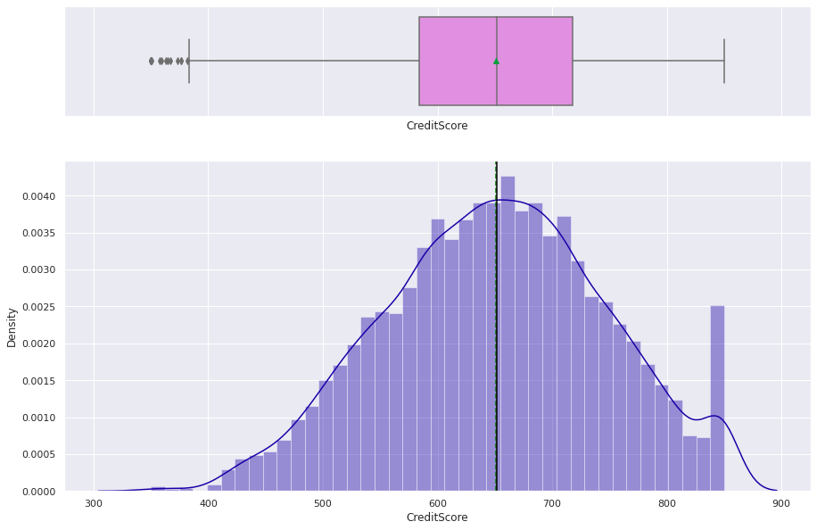

```python
# Observations on Credit Score
histogram_boxplot(ccattr["CreditScore"])
```

- It is skewed to left side and looks like there are outliers on left side.

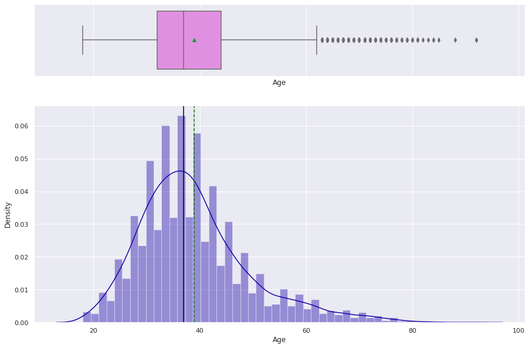

```python
# Observations on Age
histogram_boxplot(ccattr["Age"])
```

- Age is skewed to right side and there are 2 outliers which has age greater than 90

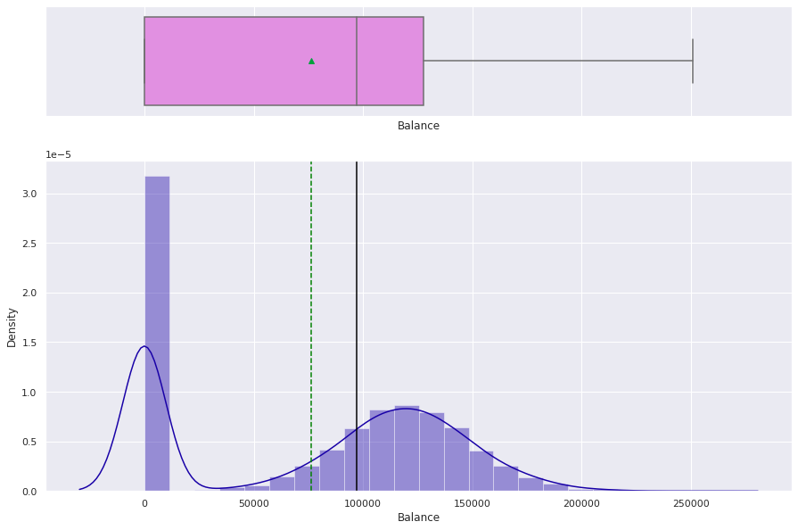

```python
# Observations on Balance
histogram_boxplot(ccattr["Balance"])
```

- Around 3500 customers are having either balance has zero or less than 10000

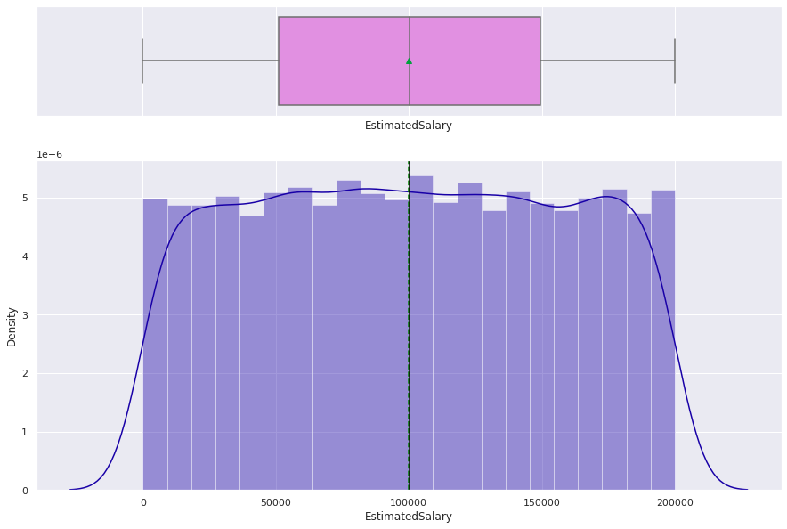

```python
# Observations on EstimatedSalary
histogram_boxplot(ccattr["EstimatedSalary"])
```

- It infers there is no skewness in the data.
- Need to check further whether it can be converted to into buckets as it has 9999 different values in the dataset.

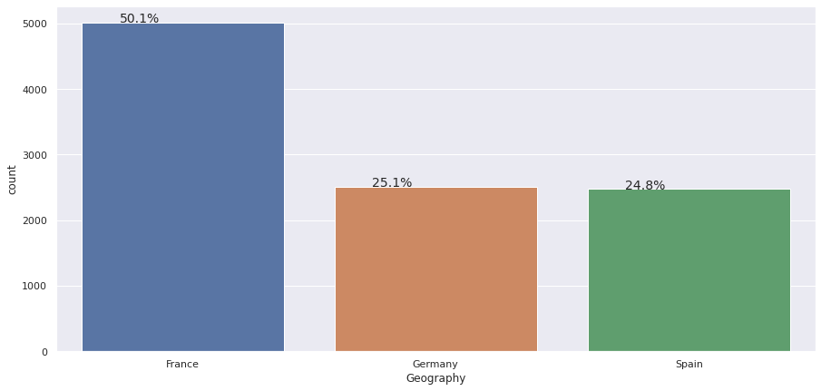

```python
# Bar plot for Geography
perc_on_bar(ccattr["Geography"])
```

- France has More observations than others.

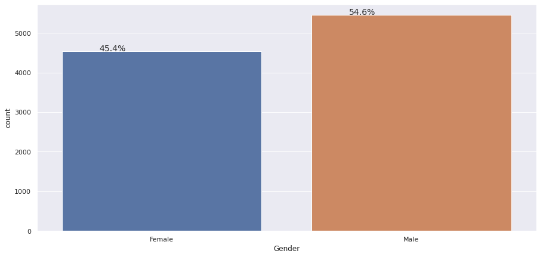

```python
# Bar plot for Gender
perc_on_bar(ccattr["Gender"])
```

- Male Gender has more observations

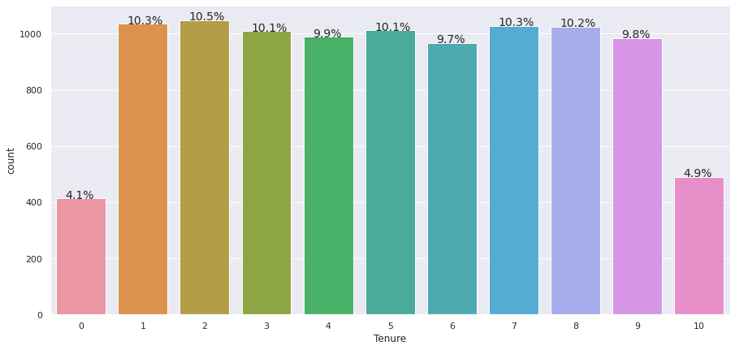

```python
# Bar plot for Tenure
perc_on_bar(ccattr["Tenure"])
```

- Customers staying with the bank are low at Tenure 0 as well as at Tenure 10 years.

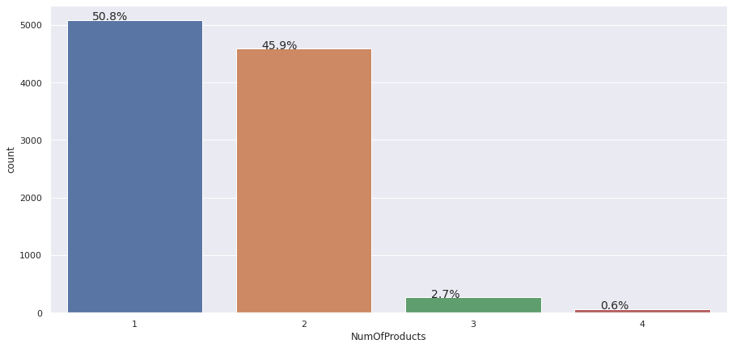

```python
# Bar plot for NumOfProducts
perc_on_bar(ccattr["NumOfProducts"])
```

- Only a few customers are having number of products as 4
- Number of products carrying a customer is decreasing when the number of products are increasing.

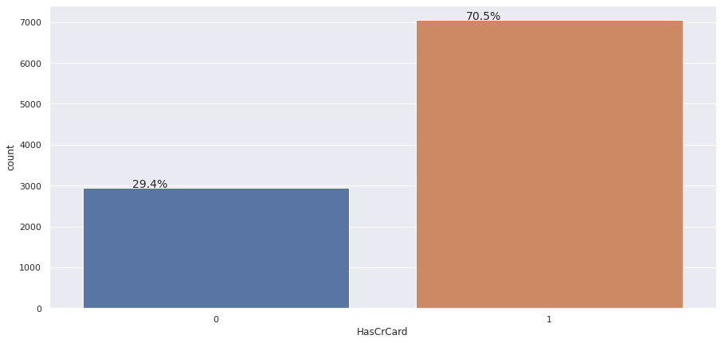

```python
# Bar plot for HasCrCard
perc_on_bar(ccattr["HasCrCard"])
```

- Customers having credit card has more observations.

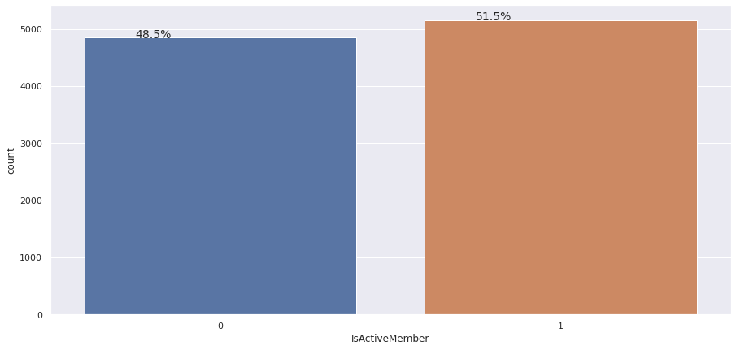

```python
# Bar plot for IsActiveMember
perc_on_bar(ccattr["IsActiveMember"])
```

- It infers Acive customer count is little higher than nonactive customers count.

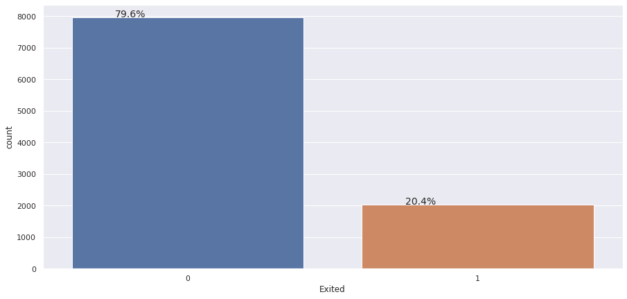

```python
# Bar plot for Exited
perc_on_bar(ccattr["Exited"])
```

- There is an inbalance in the target variables as exited customer count is lot less than the existing customers.

# BiVariate Analysis

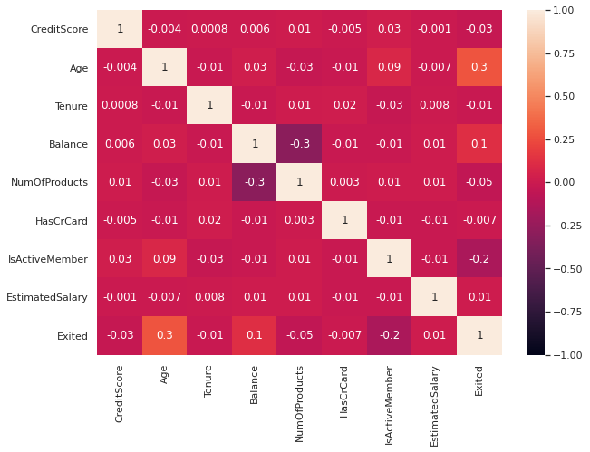

```python
# Generating Heat Map
plt.figure(figsize=(10,7))
sns.heatmap(ccattr.corr(),annot=True,vmin=-1,vmax=1,fmt='.1g')
plt.show()
```

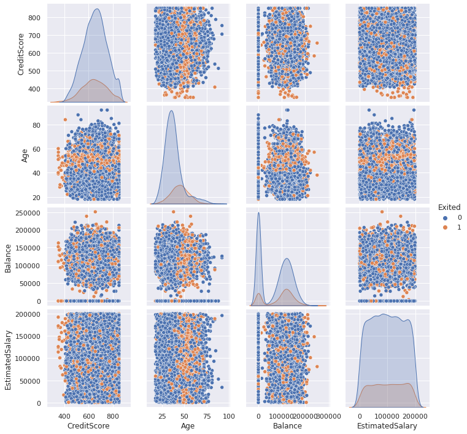

```python
# Pair plot with hue as Exited flag
sns.pairplot(ccattr, vars=['CreditScore','Age','Balance','EstimatedSalary'], hue='Exited')
```

- Not able to gather much information from the pair plot.

```python
### Function to plot stacked bar charts for categorical columns
def stacked_plot(x):
    sns.set(palette="nipy_spectral")
    tab1 = pd.crosstab(x, ccdata["Exited"], margins=True)
    print(tab1)
    print("-" * 120)
    tab = pd.crosstab(x, ccdata["Exited"], normalize="index")
    tab.plot(kind="bar", stacked=True, figsize=(10, 5))
    plt.legend(loc="lower left", frameon=False)
    plt.legend(loc="upper left", bbox_to_anchor=(1, 1))
    plt.show()
```

```
Exited        0     1    All
Geography
France     4204   810   5014
Germany    1695   814   2509
Spain      2064   413   2477
All        7963  2037  10000
------------------------------------------------------------------------------------------------------------------------
```

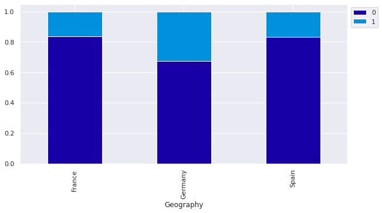

```python
# Stacked plot for the Geography.
stacked_plot(ccattr["Geography"])
```

- Germany customers has more tendency to exit the bank.

```
Exited     0     1    All
Gender
Female  3404  1139   4543
Male    4559   898   5457
All     7963  2037  10000
------------------------------------------------------------------------------------------------------------------------
```

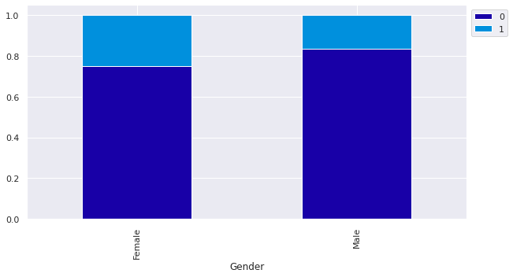

```python
# Stacked plot for the Gender.
stacked_plot(ccattr["Gender"])
```

- Gender female has more tendency to exit the bank.

```
Exited     0     1    All
Tenure
0        318    95    413
1        803   232   1035
2        847   201   1048
3        796   213   1009
4        786   203    989
5        803   209   1012
6        771   196    967
7        851   177   1028
8        828   197   1025
9        771   213    984
10       389   101    490
All     7963  2037  10000
------------------------------------------------------------------------------------------------------------------------
```

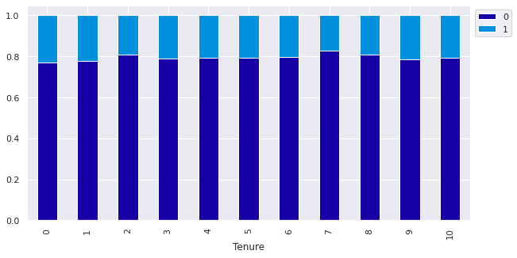

```python
# Stacked plot for the Tenure.
stacked_plot(ccattr["Tenure"])
```

```
Exited            0     1    All
NumOfProducts
1              3675  1409   5084
2              4242   348   4590
3                46   220    266
4                 0    60     60
All            7963  2037  10000
------------------------------------------------------------------------------------------------------------------------
```

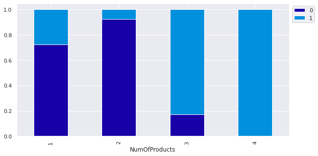

```python
# Stacked plot for the NumOfProducts.
stacked_plot(ccattr["NumOfProducts"])
```

- Customers having more number of products has more tendency to leave the bank and that is true with customers having number of products as 3 and 4.

```
Exited        0     1    All
HasCrCard
0          2332   613   2945
1          5631  1424   7055
All        7963  2037  10000
------------------------------------------------------------------------------------------------------------------------
```

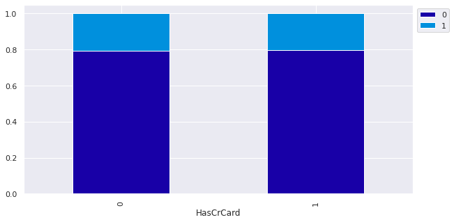

```python
# Stacked plot for the Gender.
stacked_plot(ccattr["HasCrCard"])
```

-Having credit card or not is not impacting the exited customer flag.

```
Exited             0     1    All
IsActiveMember
0               3547  1302   4849
1               4416   735   5151
All             7963  2037  10000
------------------------------------------------------------------------------------------------------------------------
```

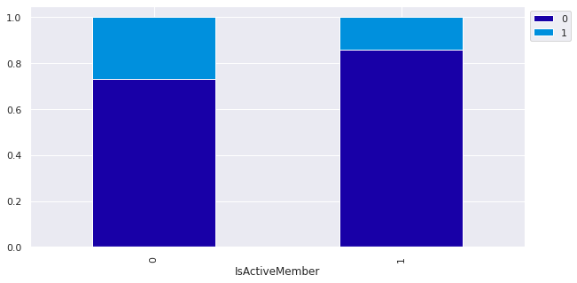

```python
# Stacked plot for the Gender.
stacked_plot(ccattr["IsActiveMember"])
```

- Activecustomers has less tendency to leave the bank.

# Data Processing for the model.

```python
# Checking outliers on credit score
ccattr[ccattr['CreditScore']<400].sort_values(by='CreditScore')
```

|  | CreditScore | Geography | Gender | Age | Tenure | Balance | NumOfProducts | HasCrCard | IsActiveMember | EstimatedSalary | Exited |
| --- | --- | --- | --- | --- | --- | --- | --- | --- | --- | --- | --- |
| 9624 | 350 | France | Female | 40 | 0 | 111098.85 | 1 | 1 | 1 | 172321.21 | 1 |
| 8762 | 350 | France | Female | 60 | 3 | 0.00 | 1 | 0 | 0 | 113796.15 | 1 |
| 8723 | 350 | France | Male | 51 | 10 | 0.00 | 1 | 1 | 1 | 125823.79 | 1 |
| 1631 | 350 | Spain | Male | 54 | 1 | 152677.48 | 1 | 1 | 1 | 191973.49 | 1 |
| 1838 | 350 | Germany | Male | 39 | 0 | 109733.20 | 2 | 0 | 0 | 123602.11 | 1 |
| 2473 | 351 | Germany | Female | 57 | 4 | 163146.46 | 1 | 1 | 0 | 169621.69 | 1 |
| 1962 | 358 | Spain | Female | 52 | 8 | 143542.36 | 3 | 1 | 0 | 141959.11 | 1 |
| 1405 | 359 | France | Female | 44 | 6 | 128747.69 | 1 | 1 | 0 | 146955.71 | 1 |
| 1193 | 363 | Spain | Female | 28 | 6 | 146098.43 | 3 | 1 | 0 | 100615.14 | 1 |
| 2579 | 365 | Germany | Male | 30 | 0 | 127760.07 | 1 | 1 | 0 | 81537.85 | 1 |
| 8154 | 367 | Spain | Male | 42 | 6 | 93608.28 | 1 | 1 | 0 | 168816.73 | 1 |
| 9356 | 373 | France | Male | 42 | 7 | 0.00 | 1 | 1 | 0 | 77786.37 | 1 |
| 942 | 376 | France | Female | 46 | 6 | 0.00 | 1 | 1 | 0 | 157333.69 | 1 |
| 7 | 376 | Germany | Female | 29 | 4 | 115046.74 | 4 | 1 | 0 | 119346.88 | 1 |
| 9210 | 382 | Spain | Male | 36 | 0 | 0.00 | 1 | 1 | 1 | 179540.73 | 1 |
| 5494 | 383 | Spain | Female | 48 | 8 | 95808.19 | 1 | 0 | 0 | 137702.01 | 1 |
| 5285 | 386 | Spain | Female | 53 | 1 | 131955.07 | 1 | 1 | 1 | 62514.65 | 1 |
| 6253 | 395 | Germany | Female | 34 | 5 | 106011.59 | 1 | 1 | 1 | 17376.57 | 1 |
| 1201 | 399 | Germany | Male | 46 | 2 | 127655.22 | 1 | 1 | 0 | 139994.68 | 1 |

- There are 5 observations that has 350 as a credit score but that doesn't look like an outlier.

```python
# Checking outliers on Age
ccattr[ccattr['Age']>80].sort_values(by='Age')
```

|  | CreditScore | Geography | Gender | Age | Tenure | Balance | NumOfProducts | HasCrCard | IsActiveMember | EstimatedSalary | Exited |
| --- | --- | --- | --- | --- | --- | --- | --- | --- | --- | --- | --- |
| 4931 | 682 | Germany | Male | 81 | 6 | 122029.15 | 1 | 1 | 1 | 50783.88 | 0 |
| 7526 | 850 | France | Female | 81 | 1 | 0.00 | 2 | 1 | 1 | 59568.24 | 0 |
| 7956 | 850 | France | Male | 81 | 5 | 0.00 | 2 | 1 | 1 | 44827.47 | 0 |
| 9080 | 711 | France | Female | 81 | 6 | 0.00 | 2 | 1 | 1 | 72276.24 | 0 |
| 766 | 700 | France | Female | 82 | 2 | 0.00 | 2 | 0 | 1 | 182055.36 | 0 |
| 9309 | 678 | Germany | Male | 83 | 6 | 123356.63 | 1 | 0 | 1 | 92934.41 | 0 |
| 3387 | 537 | Germany | Male | 84 | 8 | 92242.34 | 1 | 1 | 1 | 186235.98 | 0 |
| 3531 | 408 | France | Female | 84 | 8 | 87873.39 | 1 | 0 | 0 | 188484.52 | 1 |
| 3033 | 787 | France | Female | 85 | 10 | 0.00 | 2 | 1 | 1 | 116537.96 | 0 |
| 2458 | 513 | Spain | Male | 88 | 10 | 0.00 | 2 | 1 | 1 | 52952.24 | 0 |
| 6443 | 753 | France | Male | 92 | 3 | 121513.31 | 1 | 0 | 1 | 195563.99 | 0 |
| 6759 | 705 | France | Male | 92 | 1 | 126076.24 | 2 | 1 | 1 | 34436.83 | 0 |

There are 2 records that has age has 92 years, these can be removed from the dataset as it doesn't help much to the model.

```python
# Deleting 2 records for which customers having age as 92
ccattr = ccattr[ccattr.Age != 92]
```

```python
# Checking outliers on Balance
ccattr[ccattr['Balance']==0].sort_values(by='Balance')
```

|  | CreditScore | Geography | Gender | Age | Tenure | Balance | NumOfProducts | HasCrCard | IsActiveMember | EstimatedSalary | Exited |
| --- | --- | --- | --- | --- | --- | --- | --- | --- | --- | --- | --- |
| 0 | 619 | France | Female | 42 | 2 | 0.0 | 1 | 1 | 1 | 101348.88 | 1 |
| 6647 | 713 | France | Female | 37 | 8 | 0.0 | 1 | 1 | 1 | 16403.41 | 0 |
| 6652 | 827 | France | Male | 38 | 5 | 0.0 | 2 | 0 | 0 | 103305.01 | 0 |
| 6657 | 660 | Spain | Male | 33 | 4 | 0.0 | 1 | 1 | 0 | 29664.45 | 0 |
| 6658 | 628 | France | Female | 31 | 5 | 0.0 | 1 | 0 | 0 | 147963.07 | 1 |
| ... | ... | ... | ... | ... | ... | ... | ... | ... | ... | ... | ... |
| 3420 | 680 | France | Male | 31 | 1 | 0.0 | 2 | 1 | 1 | 3148.20 | 0 |
| 3424 | 688 | Spain | Male | 42 | 5 | 0.0 | 2 | 0 | 0 | 197602.29 | 0 |
| 3426 | 581 | Spain | Male | 49 | 10 | 0.0 | 2 | 0 | 0 | 41623.59 | 0 |
| 3341 | 718 | France | Female | 29 | 3 | 0.0 | 1 | 0 | 1 | 134462.29 | 0 |
| 9997 | 709 | France | Female | 36 | 7 | 0.0 | 1 | 0 | 1 | 42085.58 | 1 |

3617 rows × 11 columns

- There are 3617 that has 0 as balance and should not consider these are outliers.

```python
# Checking the NumofProducts when it is 4
ccattr[ccattr['NumOfProducts']==4].sort_values(by='NumOfProducts')
```

|  | CreditScore | Geography | Gender | Age | Tenure | Balance | NumOfProducts | HasCrCard | IsActiveMember | EstimatedSalary | Exited |
| --- | --- | --- | --- | --- | --- | --- | --- | --- | --- | --- | --- |
| 7 | 376 | Germany | Female | 29 | 4 | 115046.74 | 4 | 1 | 0 | 119346.88 | 1 |
| 5137 | 698 | France | Female | 51 | 6 | 144237.91 | 4 | 1 | 0 | 157143.61 | 1 |
| 5235 | 645 | France | Female | 68 | 9 | 0.00 | 4 | 1 | 1 | 176353.87 | 1 |
| 5386 | 642 | France | Male | 48 | 9 | 118317.27 | 4 | 0 | 0 | 78702.98 | 1 |
| 5700 | 447 | France | Male | 41 | 3 | 0.00 | 4 | 1 | 1 | 197490.39 | 1 |
| 5904 | 692 | Germany | Male | 45 | 6 | 142084.04 | 4 | 1 | 0 | 188305.85 | 1 |
| 6150 | 632 | Germany | Male | 41 | 8 | 127205.32 | 4 | 1 | 0 | 93874.87 | 1 |
| 6172 | 568 | Germany | Male | 43 | 5 | 87612.64 | 4 | 1 | 1 | 107155.40 | 1 |
| 6279 | 757 | Spain | Female | 55 | 9 | 117294.12 | 4 | 1 | 0 | 94187.47 | 1 |
| 6750 | 618 | France | Female | 42 | 2 | 0.00 | 4 | 0 | 0 | 111097.39 | 1 |
| 6875 | 610 | France | Female | 57 | 7 | 72092.95 | 4 | 0 | 1 | 113228.82 | 1 |
| 7257 | 747 | France | Female | 47 | 5 | 139914.60 | 4 | 0 | 1 | 129964.56 | 1 |
| 7457 | 665 | Germany | Female | 43 | 2 | 116322.27 | 4 | 1 | 0 | 35640.12 | 1 |
| 5010 | 575 | Germany | Male | 49 | 7 | 121205.15 | 4 | 1 | 1 | 168080.53 | 1 |
| 7567 | 629 | France | Male | 44 | 5 | 0.00 | 4 | 0 | 0 | 117572.59 | 1 |
| 7724 | 842 | France | Male | 44 | 3 | 141252.18 | 4 | 0 | 1 | 128521.16 | 1 |
| 7729 | 850 | France | Female | 35 | 2 | 128548.49 | 4 | 1 | 0 | 75478.95 | 1 |
| 8041 | 698 | Spain | Female | 50 | 1 | 0.00 | 4 | 1 | 0 | 88566.90 | 1 |
| 8590 | 771 | France | Female | 41 | 10 | 108309.00 | 4 | 1 | 1 | 137510.41 | 1 |
| 8683 | 697 | France | Female | 49 | 7 | 195238.29 | 4 | 0 | 1 | 131083.56 | 1 |
| 8850 | 500 | Spain | Female | 50 | 5 | 0.00 | 4 | 1 | 1 | 83866.35 | 1 |
| 8923 | 625 | Germany | Female | 55 | 8 | 118772.71 | 4 | 0 | 0 | 135853.62 | 1 |
| 9215 | 584 | Germany | Female | 37 | 10 | 134171.80 | 4 | 1 | 1 | 70927.11 | 1 |
| 9255 | 847 | Germany | Female | 41 | 3 | 101543.51 | 4 | 1 | 0 | 16025.17 | 1 |
| 9323 | 644 | France | Male | 50 | 9 | 76817.00 | 4 | 1 | 0 | 196371.13 | 1 |
| 9370 | 561 | France | Male | 43 | 4 | 0.00 | 4 | 0 | 0 | 18522.91 | 1 |
| 9411 | 689 | Germany | Female | 40 | 4 | 78119.59 | 4 | 1 | 0 | 119259.34 | 1 |
| 7698 | 592 | France | Male | 60 | 9 | 0.00 | 4 | 1 | 1 | 13614.01 | 1 |
| 4822 | 745 | France | Female | 32 | 2 | 0.00 | 4 | 0 | 1 | 179705.13 | 1 |
| 4748 | 537 | Germany | Female | 37 | 7 | 158411.95 | 4 | 1 | 1 | 117690.58 | 1 |
| 4654 | 578 | Germany | Female | 31 | 5 | 102088.68 | 4 | 0 | 0 | 187866.21 | 1 |
| 70 | 738 | Germany | Male | 58 | 2 | 133745.44 | 4 | 1 | 0 | 28373.86 | 1 |
| 1254 | 628 | France | Female | 46 | 1 | 46870.43 | 4 | 1 | 0 | 31272.14 | 1 |
| 1469 | 819 | Germany | Female | 49 | 1 | 120656.86 | 4 | 0 | 0 | 166164.30 | 1 |
| 1488 | 596 | Spain | Male | 30 | 6 | 121345.88 | 4 | 1 | 0 | 41921.75 | 1 |
| 1701 | 792 | France | Male | 50 | 9 | 0.00 | 4 | 1 | 1 | 194700.81 | 1 |
| 1876 | 640 | Germany | Male | 39 | 9 | 131607.28 | 4 | 0 | 1 | 6981.43 | 1 |
| 2124 | 704 | France | Male | 32 | 7 | 127785.17 | 4 | 0 | 0 | 184464.70 | 1 |
| 2196 | 773 | Germany | Male | 47 | 2 | 118079.47 | 4 | 1 | 1 | 143007.49 | 1 |
| 2285 | 630 | Germany | Male | 50 | 3 | 129370.91 | 4 | 1 | 1 | 47775.34 | 1 |
| 2462 | 672 | France | Female | 53 | 9 | 169406.33 | 4 | 1 | 1 | 147311.47 | 1 |
| 2499 | 614 | France | Female | 37 | 8 | 75150.34 | 4 | 0 | 1 | 131766.67 | 1 |
| 2509 | 655 | France | Female | 50 | 10 | 0.00 | 4 | 1 | 0 | 179267.94 | 1 |
| 2541 | 611 | France | Female | 61 | 3 | 131583.59 | 4 | 0 | 1 | 66238.23 | 1 |
| 2614 | 546 | Germany | Female | 58 | 3 | 106458.31 | 4 | 1 | 0 | 128881.87 | 1 |
| 2617 | 692 | Germany | Male | 45 | 6 | 152296.83 | 4 | 0 | 1 | 108040.86 | 1 |
| 2872 | 439 | Spain | Male | 52 | 3 | 96196.24 | 4 | 1 | 0 | 198874.52 | 1 |
| 3152 | 644 | France | Female | 40 | 9 | 137285.26 | 4 | 1 | 0 | 77063.63 | 1 |
| 3365 | 671 | Spain | Female | 34 | 5 | 130929.02 | 4 | 1 | 1 | 28238.25 | 1 |
| 3841 | 653 | France | Female | 60 | 2 | 120731.39 | 4 | 1 | 1 | 138160.11 | 1 |
| 4013 | 720 | Germany | Female | 57 | 1 | 162082.31 | 4 | 0 | 0 | 27145.73 | 1 |
| 4014 | 641 | Germany | Female | 51 | 2 | 117306.69 | 4 | 1 | 1 | 26912.72 | 1 |
| 4166 | 850 | Spain | Female | 45 | 5 | 174088.30 | 4 | 1 | 0 | 5669.31 | 1 |
| 4260 | 587 | France | Male | 40 | 2 | 0.00 | 4 | 0 | 1 | 106174.70 | 1 |
| 4403 | 602 | Germany | Female | 43 | 2 | 113641.49 | 4 | 1 | 0 | 115116.35 | 1 |
| 4511 | 634 | France | Female | 45 | 2 | 0.00 | 4 | 1 | 0 | 101039.53 | 1 |
| 4516 | 497 | Germany | Female | 32 | 8 | 111537.23 | 4 | 1 | 1 | 9497.99 | 1 |
| 4606 | 797 | France | Female | 55 | 10 | 0.00 | 4 | 1 | 1 | 49418.87 | 1 |
| 9540 | 727 | Germany | Male | 46 | 3 | 115248.11 | 4 | 1 | 0 | 130752.01 | 1 |
| 9565 | 582 | France | Female | 38 | 9 | 135979.01 | 4 | 1 | 1 | 76582.95 | 1 |

- There are 60 observation, which has numberofproducts as 4 and all of them exited from the bank, it infers when the customer having numberof products as 4 is exiting the bank.
- Will check the modle performance later whether removing the data points when the number of products is 4 to make the model more generalized.

```python
# Converting Creditscore to Categorical Variable to check whehter it can help to improve the metrics, but not seeing any improvement.
bins = [349, 584, 652, 718, 851]

cats = ['1', '2', '3', '4']
ccattr["CreditScore"] = pd.cut(ccattr['CreditScore'], bins, labels=cats)
ccattr["CreditScore"]
```

```
0       2
1       2
2       1
3       3
4       4
       ..
9995    4
9996    1
9997    3
9998    4
9999    4
Name: CreditScore, Length: 9998, dtype: category
Categories (4, object): ['1' < '2' < '3' < '4']
```

```python
# Converting the Categorical Variables to number to improve the performance of the model.
replaceStruct = {
                "Gender":     {"Female": 1, "Male": 2},
                "Geography": {"France": 1, "Germany": 2 , "Spain": 3}
               }
```

```python
ccattr=ccattr.replace(replaceStruct)
```

```python
# Creating dummy columns through one hot for CreditScore, Geography, Gender,Tenure,NUmbofProducts,HascrCard
ccattr = pd.get_dummies(ccattr, columns=["CreditScore","Geography","Gender","Tenure","NumOfProducts"],drop_first=False)
```

```python
# Standardizing the Age, Balance, estimatesalary into single unit for the model to work best.
from sklearn.preprocessing import StandardScaler
ccattr['Age'] = StandardScaler().fit_transform(ccattr['Age'].values.reshape(-1,1))  # Normalize 'Amount' in [-1,+1] range
ccattr['Balance'] = StandardScaler().fit_transform(ccattr['Balance'].values.reshape(-1,1))  # Normalize 'Amount' in [-1,+1] range
ccattr['EstimatedSalary'] = StandardScaler().fit_transform(ccattr['EstimatedSalary'].values.reshape(-1,1))  # Normalize 'Amount' in [-1,+1] range
```

# Model evaluation criterion:

# Model can make wrong predictions as:

- Predicting a customer will leave the bank but the customer doesn't leave the bank, bank resources contact the customers to try to retain them that can incurr resource cost.
- Predicting a customer will not leave the bank, but actually leaves the bank - Loss of opportunity for the Bank. Bank will not reach out these customers hence the model predicted them as they stay with the bank but acutally the customer leaves the bank that causes the bank to lost revenue. # Which case is more important?
- Predicting a customer will not leave the bank, but acutally the customer does i.e. losing revenue for the bank by missing the customer. As the customer may not be contacted by the bank team when he should be contacted.
- How to reduce this loss i.e need to reduce False Negatives, which is nothing but recall
- Bank wants Recall to be maximized, greater the Recall lesser the chances of false negatives.

```python
# Separating target variable and other variables
X = ccattr.drop(columns="Exited")
y = ccattr["Exited"]
```

```python
# Splitting the data into train and test sets
X_train, X_test, y_train, y_test = train_test_split(
    X, y, test_size=0.20, random_state=1, stratify=y)
print(X_train.shape, X_test.shape)
print('y_train value count',y_train.value_counts())
print('y_test value count',y_test.value_counts())
```

```
(7998, 29) (2000, 29)
y_train value count 0    6368
1    1630
Name: Exited, dtype: int64
y_test value count 0    1593
1     407
Name: Exited, dtype: int64
```

```python
#Buidling Confusion Matrix
def make_confusion_matrix(cf,
                          group_names=None,
                          categories='auto',
                          count=True,
                          percent=True,
                          cbar=True,
                          xyticks=True,
                          xyplotlabels=True,
                          sum_stats=True,
                          figsize=None,
                          cmap='Blues',
                          title=None):
    '''
    This function will make a pretty plot of an sklearn Confusion Matrix cm using a Seaborn heatmap visualization.
    Arguments
    '''


    # CODE TO GENERATE TEXT INSIDE EACH SQUARE
    blanks = ['' for i in range(cf.size)]

    if group_names and len(group_names)==cf.size:
        group_labels = ["{}\n".format(value) for value in group_names]
    else:
        group_labels = blanks

    if count:
        group_counts = ["{0:0.0f}\n".format(value) for value in cf.flatten()]
    else:
        group_counts = blanks

    if percent:
        group_percentages = ["{0:.2%}".format(value) for value in cf.flatten()/np.sum(cf)]
    else:
        group_percentages = blanks

    box_labels = [f"{v1}{v2}{v3}".strip() for v1, v2, v3 in zip(group_labels,group_counts,group_percentages)]
    box_labels = np.asarray(box_labels).reshape(cf.shape[0],cf.shape[1])


    # CODE TO GENERATE SUMMARY STATISTICS & TEXT FOR SUMMARY STATS
    if sum_stats:
        #Accuracy is sum of diagonal divided by total observations
        accuracy  = np.trace(cf) / float(np.sum(cf))

        #if it is a binary confusion matrix, show some more stats
        if len(cf)==2:
            #Metrics for Binary Confusion Matrices
            precision = cf[1,1] / sum(cf[:,1])
            recall    = cf[1,1] / sum(cf[1,:])
            f1_score  = 2*precision*recall / (precision + recall)
            stats_text = "\n\nAccuracy={:0.3f}\nPrecision={:0.3f}\nRecall={:0.3f}\nF1 Score={:0.3f}".format(
                accuracy,precision,recall,f1_score)
        else:
            stats_text = "\n\nAccuracy={:0.3f}".format(accuracy)
    else:
        stats_text = ""


    # SET FIGURE PARAMETERS ACCORDING TO OTHER ARGUMENTS
    if figsize==None:
        #Get default figure size if not set
        figsize = plt.rcParams.get('figure.figsize')

    if xyticks==False:
        #Do not show categories if xyticks is False
        categories=False


    # MAKE THE HEATMAP VISUALIZATION
    plt.figure(figsize=figsize)
    sns.heatmap(cf,annot=box_labels,fmt="",cmap=cmap,cbar=cbar,xticklabels=categories,yticklabels=categories)

    if xyplotlabels:
        plt.ylabel('True label')
        plt.xlabel('Predicted label' + stats_text)
    else:
        plt.xlabel(stats_text)

    if title:
        plt.title(title)
```

## Let's now explore Neural Network models

## Deep neural network

Model-1

- We will use a simple NN made of 4 fully-connected layers with ReLu activation. The NN takes a vector of length 29 as input. This represents the information related to each transactions, ie each line with 29 columns from the dataset. For each transaction, the final layer will output a probability distribution (sigmoid activation function) and classify either as existing customer (0) or exited customer (1).
- a dropout step is included to prevent overfitting.

### Creating a model

Keras model object can be created with Sequential class

```python
#initialize the model
model = Sequential()
```

### Adding layers [layers and activations]

```python
# This adds the input layer (by specifying input dimension) AND the first hidden layer (units)
model.add(Dense(units=16, input_dim = 29,activation='relu'))
# hidden layer
model.add(Dense(units=24,activation='relu'))
#Adding Dropout to prevent overfitting
model.add(Dropout(0.5))
model.add(Dense(24,activation='relu'))
#model.add(Dense(24,activation='relu'))
# Adding the output layer
# we have an output of 1 node, which is the the desired dimensions of our output (Exiting the bank or not)
# We use the sigmoid because we want probability outcomes
model.add(Dense(1,activation='sigmoid'))
```

### Model compile [optimizers and loss functions]

Keras model should be "compiled" prior to training

Types of loss (function) and optimizer should be designated

```python
# Create optimizer with default learning rate
# Compile the model
model.compile(optimizer='adam',loss='binary_crossentropy',metrics=['Recall'])
```

### Let's print the summary of the model

```python
model.summary()
```

```
Model: "sequential_19"
_________________________________________________________________
Layer (type)                 Output Shape              Param #
=================================================================
dense_69 (Dense)             (None, 16)                480
_________________________________________________________________
dense_70 (Dense)             (None, 24)                408
_________________________________________________________________
dropout_31 (Dropout)         (None, 24)                0
_________________________________________________________________
dense_71 (Dense)             (None, 24)                600
_________________________________________________________________
dense_72 (Dense)             (None, 1)                 25
=================================================================
Total params: 1,513
Trainable params: 1,513
Non-trainable params: 0
_________________________________________________________________
```

## Training [Forward pass and Backpropagation]

Training the model

```python
#fitting the model
history=model.fit(X_train,y_train,batch_size=20,epochs=15,validation_split=0.2)
```

Plotting the train and test loss

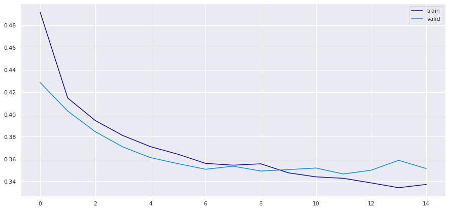

```python
# Capturing learning history per epoch
hist  = pd.DataFrame(history.history)
hist['epoch'] = history.epoch

# Plotting accuracy at different epochs
plt.plot(hist['loss'])
plt.plot(hist['val_loss'])
plt.legend(("train" , "valid") , loc =0)
```

### Evaluation

Evaluation results are contained in a list

```python
score = model.evaluate(X_test, y_test)
```

- The model achieves an recall of 47.91% ! Is this a good performance ?
- With this prediction model, 52% of the customers on test data left the bank and the model didn't predict them, it could impact on the revenue of the company.

```python
print(score)
```

```
[0.36167091131210327, 0.47911548614501953]
```

- Finding the Optimal Threshold

```
Best Threshold=0.375245, F-Score=0.599
```

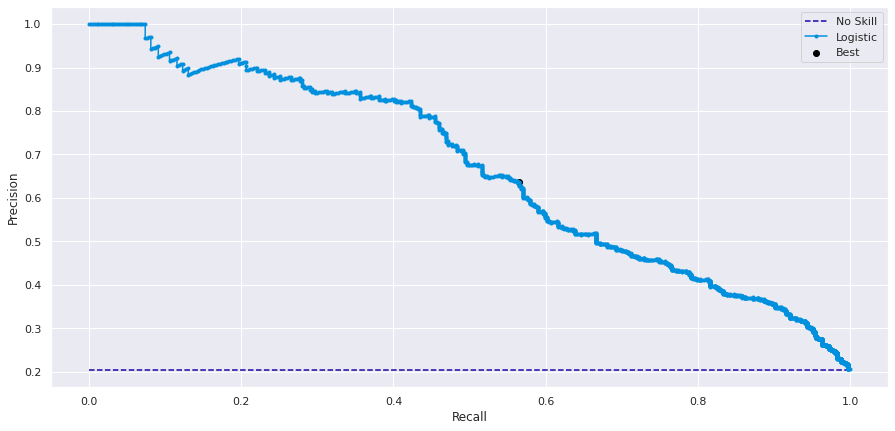

```python
# predict probabilities
yhat = model.predict_proba(X_test)
# keep probabilities for the positive outcome only
#yhat = yhat[:, 0]
# calculate roc curves
precision, recall, thresholds = precision_recall_curve(y_test, yhat)
# convert to f score
fscore = (2 * precision * recall) / (precision + recall)
# locate the index of the largest f score
ix = argmax(fscore)
print('Best Threshold=%f, F-Score=%.3f' % (thresholds[ix], fscore[ix]))
# plot the roc curve for the model
no_skill = len(y_test[y_test==1]) / len(y_test)
plt.plot([0,1], [no_skill,no_skill], linestyle='--', label='No Skill')
plt.plot(recall, precision, marker='.', label='Logistic')
plt.scatter(recall[ix], precision[ix], marker='o', color='black', label='Best')
# axis labels
plt.xlabel('Recall')
plt.ylabel('Precision')
plt.legend()
# show the plot
plt.show()
```

Let's Print confusion matrix with the optimal threshold value 0.37

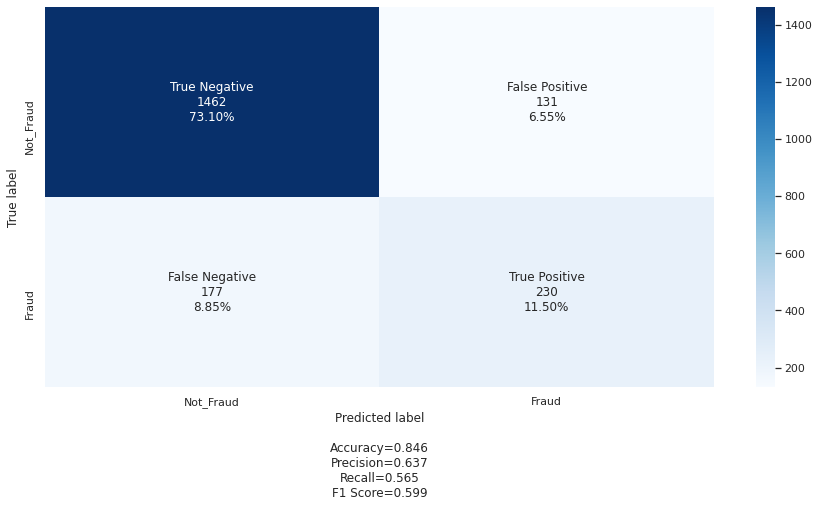

```python
## Confusion Matrix on unsee test set
import seaborn as sn
y_pred1 = model.predict(X_test)
for i in range(len(y_test)):
    if y_pred1[i]>0.375:
        y_pred1[i]=1
    else:
        y_pred1[i]=0



cm2=confusion_matrix(y_test, y_pred1)
labels = ['True Negative','False Positive','False Negative','True Positive']
categories = [ 'Not_Fraud','Fraud']
make_confusion_matrix(cm2,
                      group_names=labels,
                      categories=categories,
                      cmap='Blues')
```

- Recall is very less
- There are 177 customers who left the bank in the test data and the model didn't predict them,which remain an issue. Our objective must be to detect as many as customers who left the bank
- 131 customers are detected as exiting the bank by the model. These are false positives. This number is little high but cost of these transactions is very less.

**Conclusion:**

We must find ways to further reduce the number of false negative.

# Model-2

## Trying another architecture to get the better Recall by using hyper parameters tuning.

```python
#Training a model with 5 layers with dropout at each layer and also with initial learning rate as 0.001.

es= keras.callbacks.EarlyStopping(monitor='val_loss',
                              min_delta=0,
                              patience=15,
                             verbose=0, mode='min', restore_best_weights= True)
model2 = Sequential()



# This adds the input layer (by specifying input dimension) AND the first hidden layer (units)
model2.add(Dense(units=16, input_dim = 29,activation='relu'))
# hidden layer
model2.add(Dense(units=24,activation='relu'))
#Adding Dropout to prevent overfitting
model2.add(Dropout(0.5))
model2.add(Dense(24,activation='relu'))
model2.add(Dropout(0.5))
# Adding the output layer
# we have an output of 1 node, which is the the desired dimensions of our output (Exiting the bank or not)
# We use the sigmoid because we want probability outcomes
model2.add(Dense(1,activation='sigmoid'))

model2.compile(Adam(lr=0.01), loss='binary_crossentropy', metrics=['Recall'])

his_mod2= model2.fit(X_train, y_train, validation_split=0.2, batch_size=150, epochs=25, callbacks=[es], shuffle=True, verbose=1)
```

Plotting the train and validation loss

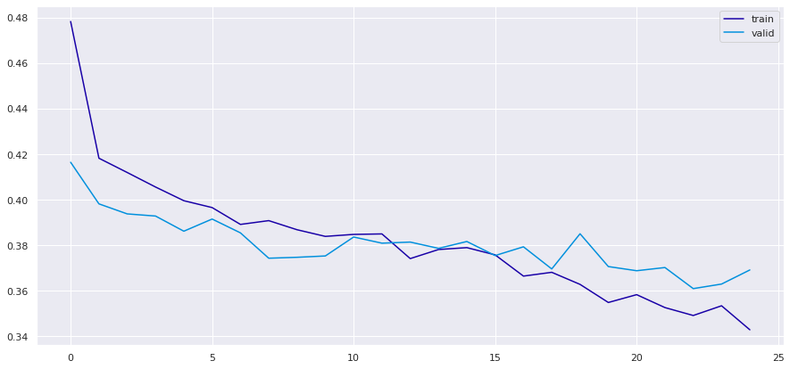

```python
# Capturing learning history per epoch
hist  = pd.DataFrame(his_mod2.history)
hist['epoch'] = his_mod2.epoch

# Plotting accuracy at different epochs
plt.plot(hist['loss'])
plt.plot(hist['val_loss'])
plt.legend(("train" , "valid") , loc =0)
```

```python
score = model2.evaluate(X_test, y_test)
```

Plotting confusion matrix

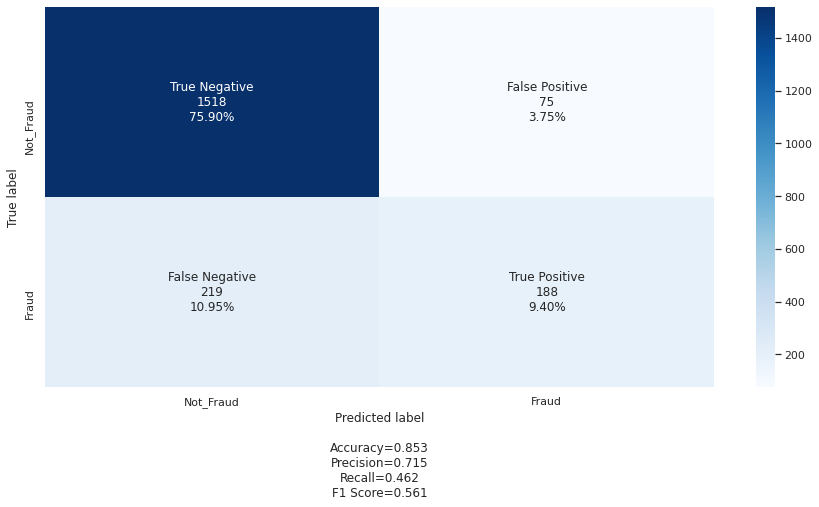

```python
## Confusion Matrix on unseen test set
import seaborn as sn
y_pred1 = model2.predict(X_test)
for i in range(len(y_test)):
    if y_pred1[i]>0.5:
        y_pred1[i]=1
    else:
        y_pred1[i]=0



cm2=confusion_matrix(y_test, y_pred1)
labels = ['True Negative','False Positive','False Negative','True Positive']
categories = [ 'Not_Fraud','Fraud']
make_confusion_matrix(cm2,
                      group_names=labels,
                      categories=categories,
                      cmap='Blues')
```

**Conclusion:**

As you can see here the Recall of the model is not improved and it is worse than the Previous ANN model.

Let's try weighted loss for imbalance dataset

### Weighted loss to account for large class imbalance in train dataset

- we will adjust the class imbalance by giving additional weight to the loss associated to errors made on fraudulent transaction detection.

We will use our first ANN model and apply weighted loss

Let's review the process:

```python
from sklearn.utils import class_weight
class_weights = class_weight.compute_class_weight('balanced', np.unique(y_train), np.array([y_train.iloc[i] for i in range(len(y_train))]))
class_weights = dict(enumerate(class_weights))
class_weights
```

```
{0: 0.6279836683417085, 1: 2.453374233128834}
```

- The class 'exited' (y=1) is assigned a weight of 2.45 vs 0.62 for the class 'existing customer' due to the very low prevalence we detected during data exploration. This allows the model to give more importance to the errors made on exited cases during training.

Training the model

```python
model.fit(X_train,y_train,batch_size=15,epochs=5, class_weight=class_weights, shuffle=True)
```

```
<keras.callbacks.History at 0x7f543e878810>
```

```python
score_weighted = model.evaluate(X_test, y_test)
```

Plotting confusion matrix

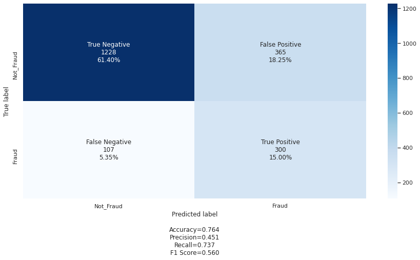

```python
## Confusion Matrix on unsee test set
import seaborn as sn
y_pred1 = model.predict(X_test)
for i in range(len(y_test)):
    if y_pred1[i]>0.5:
        y_pred1[i]=1
    else:
        y_pred1[i]=0



cm2=confusion_matrix(y_test, y_pred1)
labels = ['True Negative','False Positive','False Negative','True Positive']
categories = [ 'Not_Fraud','Fraud']
make_confusion_matrix(cm2,
                      group_names=labels,
                      categories=categories,
                      cmap='Blues')
```

Recall is imporved better than the initial AAN modle with out weight adjustments.

- There are 107 customers who left the bank in the test data and the model didn't predict them,which still remain an issue.This needs to be further improved.
- Precision metrics affected a lot after using the weightage for the target variables in the training data set.
- 365 customers are detected as exiting the bank by the model. These are false positives. This number is too high and model has to be tuned further to reduce the precision metrics.

**Model Performance Evaluation:**

As you can see here the Recall is increased by appplying the weights to the target varaibles in the train data set but the precision is very bad. There is still lot of scope of improvements as follows:

1) Hyperparameter tuning can be applied to tune the different Hyperparameters.

2) Resampling techniques can be applied to balanced the data and then train the model.

3) Model needs to be trained with different optimzers,metrices to check further whether it can immprove the performance of the model.

4) Model was trained with 4 and 5 layers approach, but it can be trained with different layers and difrent dropouts to check further it can improve the model.

5) It can be further tuned with different nuerons at each layer except the output payer to check further whether that can improve the model.

**Conclusion:**

We can select the Model-1(first ANN model) with weights on the target varaibles as our final model based on the above analysis.